# SPf66 data processing

Somya Mehra

2023-11-14

## Data input

```r
if (!dir.exists("Spf66_data_processed")) dir.create("Spf66_data_processed")

START_DATE <- as.Date("1993-10-01")
END_DATE <- as.Date("1995-07-15")
STUDY_DURATION <- as.numeric(difftime(END_DATE, START_DATE, unit="days"))

# cleaned data from SPf66 cohort
patient_metadata <- read_rds("Spf66_data_cleaned/patient_metadata.rds")
camp_absences <- read_rds("Spf66_data_cleaned/camp_absences.rds")
malaria_consultations <- read_rds("Spf66_data_cleaned/malaria_consultations.rds")
prophylactic_periods <- read.delim("Spf66_data_cleaned/prophylactic_periods.txt")

# discretisation into uniform windows
TIME_STEP <- 10
N_COHORT <- nrow(patient_metadata)
N_OBS <- STUDY_DURATION%/%TIME_STEP

YEAR <- 365%/%TIME_STEP
MAX_AGE <- 15*YEAR

SHIFT_WINDOW <- 20
MAX_PROP_MASKED <- 0.5
```

## Antimalarial treatment

Antimalarial treatment records diverge on occasion from standard treatment regimens. Here, AM=artemether, AS=artesunate, CH=chloroquine, MF=mefloquine, QU=quinine, TE=tetracycline.

| Diagnosis | Treatment | Count |
| --- | --- | --- |
| Pf | AS+MF | 720 |
| Pf | AS | 137 |
| Pf | QU+TE | 9 |
| Pf | AM | 7 |
| Pf | AS+TE | 5 |
| Pf | MF | 3 |
| Pf | QU | 2 |
| Pf | CH | 1 |
| Pv | CH | 2180 |
| Pv | AS+MF | 35 |
| Pv | AS | 9 |
| Pv+Pf | AS+MF | 266 |
| Pv+Pf | AS | 18 |
| Pv+Pf | CH | 5 |
| Pv+Pf | AS+TE | 2 |
| Pv+Pf | QU+TE | 2 |
| Pv+Pf | AM | 1 |

Inter-consultation intervals exhibit patterns consistent with post-exposure prophylaxis.

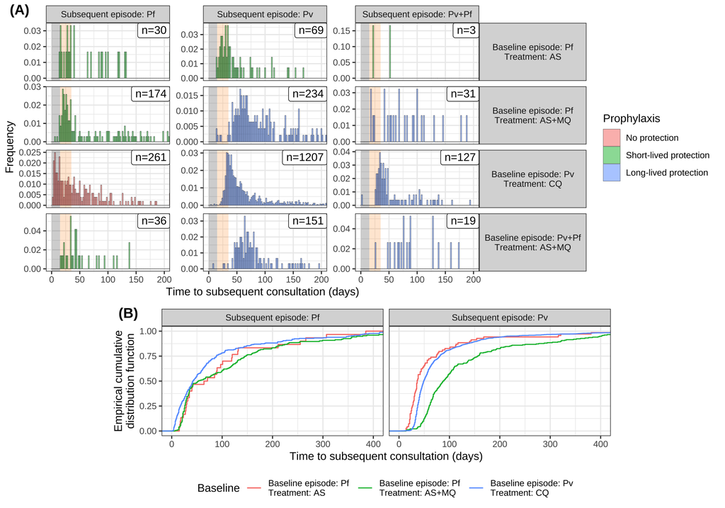

## Vivax after falciparum monoinfection

Here, we consider the time from each recorded falciparum monoinfection (treated with either artesunate monotherapy or artesunate-mefloquine combination therapy) to the subsequent vivax episode. We perform Kaplan-Meier survival analysis, adjusting for right-censoring but *not* the loss of clinical follow-up due to documented absences from the camp.

```r
Pf_monoinf <- treatment_regimens %>%
  subset(FALCIP==1 & VIVAX==0 & Treatment %in% c("AS", "AS+MF")) %>%
  transmute(VIN=VIN, PfTime=RelativeTime, Treatment=Treatment)

Pv_after_Pf_monoinf <- treatment_regimens %>% subset(VIVAX==1) %>%
  transmute(VIN=as.character(VIN), PvTime=RelativeTime) %>%
  merge(Pf_monoinf) %>% subset(PvTime>PfTime) %>%
  group_by(VIN, Treatment, PfTime) %>% dplyr::summarise(Time=min(PvTime)-PfTime) %>%
  unique %>% mutate(Status=1)

no_Pv_after_Pf_monoinf <- Pf_monoinf %>%
  subset(!(as.character(VIN) %in% as.character(Pv_after_Pf_monoinf$VIN))) %>%
  mutate(Time=as.numeric(difftime(patient_metadata[as.character(VIN), "WITH_DAT"],
                                  START_DATE, units = "days"))-PfTime, Status=0)

first_Pv_after_Pf <- bind_rows(Pv_after_Pf_monoinf, no_Pv_after_Pf_monoinf) %>%
  mutate(Group=as.numeric(Treatment=="AS"))
first_Pv_after_Pf$Prev_Pv_ep <- apply(first_Pv_after_Pf, 1, function(x)
  treatment_regimens %>% subset(as.character(VIN)==as.character(x[["VIN"]]) &
             VIVAX==1 & RelativeTime<as.numeric(x["PfTime"])) %>% nrow)

Kaplan_Meier_Pf_to_Pv_unmatched <-
  survfit(Surv(Time, Status) ~ Treatment, data=first_Pv_after_Pf)
```

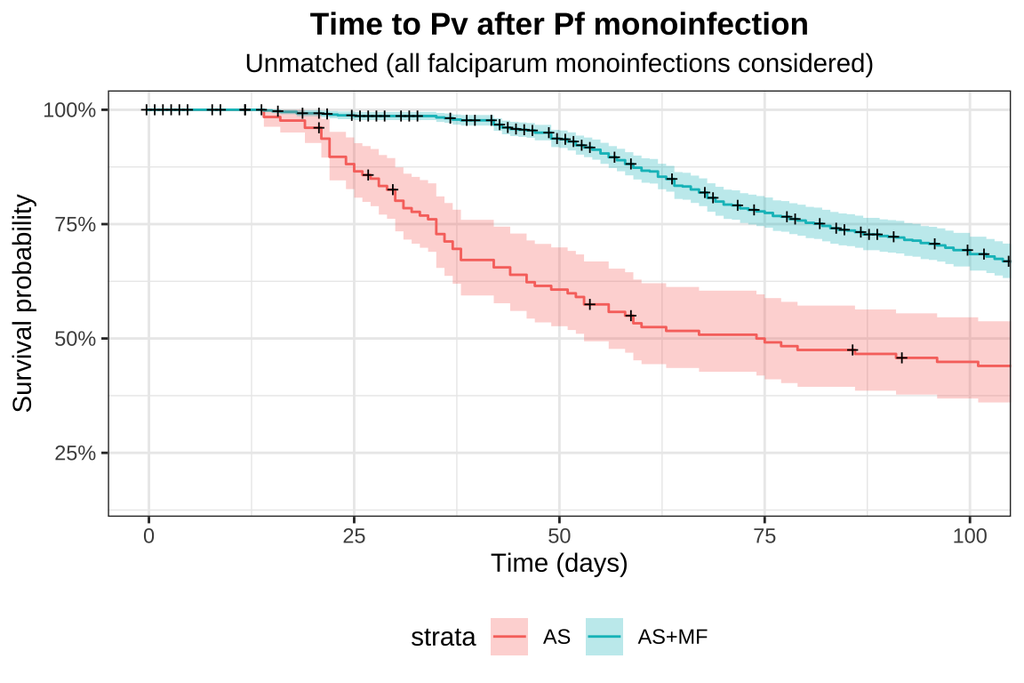

We note however that artesunate monotherapy was typically administered to children with repeated falciparum episodes that were previously treated with artestunate-mefloquine combination therapy, as a pre-emptive measure to avoid mefloquine toxicity. As such, we match the treatment groups by the time of the initial falciparum monoinfection (to control for seasonality) and the number of previous vivax episodes.

```r
match_Pf_covariates <-
  matchit(Group ~ Prev_Pv_ep + PfTime, data=first_Pv_after_Pf,
          distance="glm", method="nearest")

matched_first_Pv_after_Pf <- match.data(match_Pf_covariates)

Kaplan_Meier_Pf_to_Pv_matched <-
  survfit(Surv(Time, Status) ~ Treatment, data=matched_first_Pv_after_Pf)
```

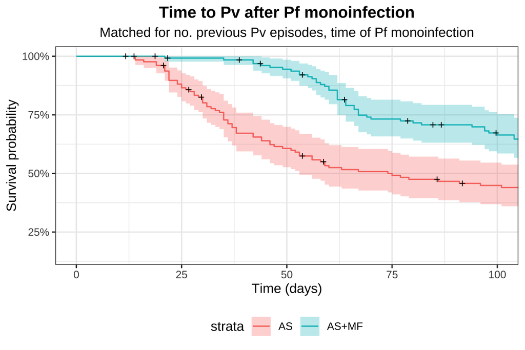

## Platelet counts

A key correlate of acute febrile malaria is thrombocytopemia (defined to be a platelet count below 150,000/mm^3). We thus consider platelet counts for each recorded consultation.

| Diagnosis | Below 150 | 150-200 | Above 200 |
| --- | --- | --- | --- |
| Pf | 0.4093079 | 0.2756563 | 0.3150358 |
| Pv | 0.3403320 | 0.3095703 | 0.3500977 |
| Pv+Pf | 0.4163701 | 0.2953737 | 0.2882562 |

[figure not shown]

## Adjusting for post-exposure prophylaxis

We model post exposure prophylaxis in two stages: an intial masking period (during which any hypnozoite activation events or immediate sporozoite development events are masked); and a subsequent bunching period (during which drug levels below the minimum inhibitory concentration delay, but do not complete suppress blood-stage infection).

| Treatment | Pv_masking | Pv_bunching | Pf_masking |
| --- | --- | --- | --- |
| AM | 15 | 0 | 15 |
| AS+MF | 35 | 0 | 15 |
| AS+TE | 15 | 0 | 15 |
| AS | 15 | 0 | 15 |
| CH | 15 | 20 | 0 |
| MF | 35 | 0 | 15 |
| QU+TE | 15 | 0 | 15 |
| QU | 15 | 0 | 15 |

Any consultations lying within the prophylactic masking window of a previous consultation (dependent on antimalarial treatment regimen) are masked as possible treatment failures.

```r
malaria_consultations <- merge(malaria_consultations, prophylactic_periods) %>%
  mutate(Treatment=ifelse(is.na(DRUG2), DRUG1, paste0(DRUG1, "+", DRUG2))) %>%
  dplyr::select(VIN, CONSLT_N, CDATE, FALCIP, VIVAX, RelativeTime, Treatment,
                VIVAX_MASKING, VIVAX_BUNCHING, FALCIP_MASKING, FALCIP_BUNCHING) %>%
  mutate(RelativeTime=as.integer(RelativeTime))

# stratify consultations by VIN and flag likely treatment failures
consultations_by_VIN <- split(malaria_consultations,
                              f=as.character(malaria_consultations$VIN)) %>%
  lapply(function(indiv_data) {
  indiv_data <- indiv_data %>% arrange(RelativeTime) %>% mutate(infection_id=1)

  if (nrow(indiv_data)==1) return(indiv_data)

  inter_obs_times <- diff(indiv_data$RelativeTime)

  prophylactic_masking <- sapply(2:nrow(indiv_data), function(i) {
    if (indiv_data[i, "FALCIP"]==0) return(indiv_data[i-1, "VIVAX_MASKING"])
    if (indiv_data[i, "VIVAX"]==0) return(indiv_data[i-1, "FALCIP_MASKING"])
    return(max(indiv_data[i-1, "FALCIP_MASKING"], indiv_data[i-1, "VIVAX_MASKING"]))
  })

  curr_id <- 1
  for (i in 2:nrow(indiv_data)) {
    if (inter_obs_times[i-1]>prophylactic_masking[i-1]) curr_id <- curr_id+1
    indiv_data[i, "infection_id"] <- curr_id
  }

  return(indiv_data)})

potential_treatment_failure <- consultations_by_VIN %>%
  lapply(function(x) x %>% group_by(infection_id) %>% summarise(count=n()) %>%
           subset(count>1) %>% merge(x)) %>% Filter(function(x) nrow(x)>0, .) %>% bind_rows
```

A list of consultations marked as potential treatment failures is provided below.

| infection_id | count | VIN | CONSLT_N | CDATE | FALCIP | VIVAX | RelativeTime | Treatment | VIVAX_MASKING | VIVAX_BUNCHING | FALCIP_MASKING | FALCIP_BUNCHING |
| --- | --- | --- | --- | --- | --- | --- | --- | --- | --- | --- | --- | --- |
| 1 | 2 | 2044D | 1 | 1993-10-27 | 1 | 1 | 26 | AS+MF | 35 | 0 | 15 | 0 |
| 1 | 2 | 2044D | 2 | 1993-11-22 | 0 | 1 | 52 | CH | 15 | 20 | 0 | 0 |
| 3 | 2 | 2100K | 3 | 1994-06-09 | 1 | 0 | 251 | AS+MF | 35 | 0 | 15 | 0 |
| 3 | 2 | 2100K | 4 | 1994-07-02 | 1 | 1 | 274 | AS | 15 | 0 | 15 | 0 |
| 5 | 2 | 2108C | 5 | 1994-06-15 | 1 | 0 | 257 | AS | 15 | 0 | 15 | 0 |
| 5 | 2 | 2108C | 6 | 1994-06-30 | 1 | 0 | 272 | AS | 15 | 0 | 15 | 0 |
| 1 | 2 | 2128P | 1 | 1993-12-27 | 1 | 0 | 87 | AS+MF | 35 | 0 | 15 | 0 |
| 1 | 2 | 2128P | 2 | 1994-01-10 | 1 | 0 | 101 | AS | 15 | 0 | 15 | 0 |
| 1 | 2 | 2209Y | 1 | 1994-03-29 | 1 | 0 | 179 | AS+MF | 35 | 0 | 15 | 0 |
| 1 | 2 | 2209Y | 2 | 1994-04-16 | 1 | 1 | 197 | AS+MF | 35 | 0 | 15 | 0 |
| 1 | 2 | 2264C | 2 | 1993-10-22 | 1 | 0 | 21 | AS | 15 | 0 | 15 | 0 |
| 1 | 2 | 2264C | 1 | 1993-10-11 | 1 | 0 | 10 | AS+MF | 35 | 0 | 15 | 0 |
| 1 | 2 | 2285W | 1 | 1993-10-14 | 1 | 1 | 13 | AS+MF | 35 | 0 | 15 | 0 |
| 1 | 2 | 2285W | 2 | 1993-10-22 | 0 | 1 | 21 | CH | 15 | 20 | 0 | 0 |
| 7 | 2 | 2294J | 7 | 1994-05-26 | 1 | 0 | 237 | AS+MF | 35 | 0 | 15 | 0 |
| 7 | 2 | 2294J | 8 | 1994-06-11 | 0 | 1 | 253 | CH | 15 | 20 | 0 | 0 |
| 1 | 2 | 3048J | 1 | 1994-02-28 | 1 | 1 | 150 | AS+MF | 35 | 0 | 15 | 0 |
| 1 | 2 | 3048J | 2 | 1994-04-03 | 0 | 1 | 184 | CH | 15 | 20 | 0 | 0 |
| 7 | 2 | 4055Y | 7 | 1995-05-29 | 0 | 1 | 605 | CH | 15 | 20 | 0 | 0 |
| 7 | 2 | 4055Y | 8 | 1995-06-12 | 0 | 1 | 619 | CH | 15 | 20 | 0 | 0 |
| 7 | 2 | 4178H | 7 | 1994-12-21 | 1 | 1 | 446 | AS+MF | 35 | 0 | 15 | 0 |
| 7 | 2 | 4178H | 8 | 1995-01-18 | 0 | 1 | 474 | CH | 15 | 20 | 0 | 0 |
| 1 | 2 | 4182P | 1 | 1995-04-28 | 1 | 0 | 574 | AS+MF | 35 | 0 | 15 | 0 |
| 1 | 2 | 4182P | 2 | 1995-05-12 | 1 | 0 | 588 | AS+MF | 35 | 0 | 15 | 0 |
| 8 | 2 | 4221P | 8 | 1994-10-09 | 0 | 1 | 373 | CH | 15 | 20 | 0 | 0 |
| 8 | 2 | 4221P | 9 | 1994-10-20 | 0 | 1 | 384 | CH | 15 | 20 | 0 | 0 |
| 1 | 2 | 5101H | 1 | 1994-02-09 | 1 | 0 | 131 | AS+MF | 35 | 0 | 15 | 0 |
| 1 | 2 | 5101H | 2 | 1994-02-16 | 1 | 0 | 138 | AS | 15 | 0 | 15 | 0 |
| 1 | 2 | 6022D | 1 | 1994-04-05 | 0 | 1 | 186 | CH | 15 | 20 | 0 | 0 |
| 1 | 2 | 6022D | 2 | 1994-04-09 | 0 | 1 | 190 | CH | 15 | 20 | 0 | 0 |
| 3 | 3 | 6073C | 3 | 1994-06-15 | 1 | 0 | 257 | AS | 15 | 0 | 15 | 0 |
| 3 | 3 | 6073C | 4 | 1994-06-29 | 0 | 1 | 271 | CH | 15 | 20 | 0 | 0 |
| 3 | 3 | 6073C | 5 | 1994-07-02 | 1 | 1 | 274 | AS | 15 | 0 | 15 | 0 |
| 2 | 2 | 8044W | 2 | 1994-04-04 | 1 | 0 | 185 | AS | 15 | 0 | 15 | 0 |
| 2 | 2 | 8044W | 3 | 1994-04-18 | 0 | 1 | 199 | CH | 15 | 20 | 0 | 0 |
| 6 | 3 | 8045X | 6 | 1995-05-29 | 1 | 0 | 605 | QU | 15 | 0 | 15 | 0 |
| 6 | 3 | 8045X | 7 | 1995-06-10 | 1 | 0 | 617 | MF | 35 | 0 | 15 | 0 |
| 6 | 3 | 8045X | 8 | 1995-06-18 | 1 | 0 | 625 | AS | 15 | 0 | 15 | 0 |
| 2 | 2 | 8065H | 2 | 1994-05-11 | 1 | 0 | 222 | AS+MF | 35 | 0 | 15 | 0 |
| 2 | 2 | 8065H | 3 | 1994-06-15 | 0 | 1 | 257 | CH | 15 | 20 | 0 | 0 |
| 1 | 2 | 8083W | 1 | 1994-04-26 | 1 | 1 | 207 | AS+MF | 35 | 0 | 15 | 0 |
| 1 | 2 | 8083W | 2 | 1994-05-23 | 1 | 1 | 234 | AS | 15 | 0 | 15 | 0 |
| 2 | 2 | 8083W | 3 | 1994-06-20 | 0 | 1 | 262 | CH | 15 | 20 | 0 | 0 |
| 2 | 2 | 8083W | 4 | 1994-06-22 | 1 | 1 | 264 | AS+MF | 35 | 0 | 15 | 0 |
| 3 | 2 | 8100B | 3 | 1994-05-26 | 1 | 0 | 237 | AS+MF | 35 | 0 | 15 | 0 |
| 3 | 2 | 8100B | 4 | 1994-06-09 | 1 | 0 | 251 | AS | 15 | 0 | 15 | 0 |
| 3 | 2 | 8139B | 3 | 1994-06-03 | 1 | 0 | 245 | AS+MF | 35 | 0 | 15 | 0 |
| 3 | 2 | 8139B | 4 | 1994-06-28 | 1 | 1 | 270 | AS | 15 | 0 | 15 | 0 |
| 1 | 2 | 8140C | 1 | 1993-11-16 | 1 | 0 | 46 | AS+MF | 35 | 0 | 15 | 0 |
| 1 | 2 | 8140C | 2 | 1993-12-01 | 0 | 1 | 61 | CH | 15 | 20 | 0 | 0 |
| 5 | 2 | 8182H | 5 | 1995-04-18 | 1 | 0 | 564 | AS+MF | 35 | 0 | 15 | 0 |
| 5 | 2 | 8182H | 6 | 1995-05-10 | 0 | 1 | 586 | CH | 15 | 20 | 0 | 0 |
| 1 | 2 | 8267Y | 1 | 1994-01-08 | 1 | 0 | 99 | AS+MF | 35 | 0 | 15 | 0 |
| 1 | 2 | 8267Y | 2 | 1994-01-22 | 0 | 1 | 113 | CH | 15 | 20 | 0 | 0 |
| 2 | 2 | 8325H | 2 | 1994-01-01 | 1 | 0 | 92 | AS+MF | 35 | 0 | 15 | 0 |
| 2 | 2 | 8325H | 3 | 1994-01-22 | 0 | 1 | 113 | CH | 15 | 20 | 0 | 0 |
| 1 | 2 | 8408W | 1 | 1994-01-11 | 1 | 0 | 102 | AS+MF | 35 | 0 | 15 | 0 |
| 1 | 2 | 8408W | 2 | 1994-01-29 | 1 | 1 | 120 | AS | 15 | 0 | 15 | 0 |
| 11 | 2 | 8409X | 11 | 1995-05-30 | 0 | 1 | 606 | CH | 15 | 20 | 0 | 0 |
| 11 | 2 | 8409X | 12 | 1995-06-09 | 0 | 1 | 616 | CH | 15 | 20 | 0 | 0 |
| 1 | 2 | 8419L | 1 | 1994-01-06 | 1 | 0 | 97 | AS+MF | 35 | 0 | 15 | 0 |
| 1 | 2 | 8419L | 2 | 1994-01-20 | 1 | 0 | 111 | AS+MF | 35 | 0 | 15 | 0 |
| 1 | 2 | 8447W | 1 | 1994-01-04 | 1 | 0 | 95 | AS+MF | 35 | 0 | 15 | 0 |
| 1 | 2 | 8447W | 2 | 1994-01-18 | 1 | 0 | 109 | AS | 15 | 0 | 15 | 0 |

We reconcile potentially discordant diagnoses within the prophylactic masking window.

```r
# reconcile treatment failures
malaria_consultations_reconciled <-
  lapply(consultations_by_VIN, function(indiv_data) {
    indiv_data %>% split(f=.$infection_id) %>% lapply(function(x) {

      if (nrow(x)==1) return(bind_cols(x, near_treatment_failure=F))

      # if VIVAX -> MIXED in quick succession, ignore first vivax episode
      # (only 2 cases, both 3 days or less)
      if (x[nrow(x)-1, "FALCIP"]==0 & x[nrow(x)-1, "VIVAX"]==1 &
          x[nrow(x), "FALCIP"]==1 & x[nrow(x), "VIVAX"]==1) {
        keep_episode <- setdiff(1:nrow(x), nrow(x)-1)
        return(bind_cols(x[keep_episode,], near_treatment_failure=T))
      }

      if (nrow(x)==1) return(bind_cols(x, near_treatment_failure=T))

      # if same diagnosis across successive consultations, record first infection
      # but extend out masking period to span until the last treatment --- then add
      # BUNCHING from last treatment
      if (nrow(unique(x[,c("FALCIP", "VIVAX")]))==1) {
        x[1, "VIVAX_MASKING"] <- max(x$RelativeTime)-min(x$RelativeTime)+tail(x$VIVAX_MASKING, 1)
        x[1, "VIVAX_BUNCHING"] <- tail(x$VIVAX_BUNCHING, 1)

        if (x[1, "FALCIP"]==1) {
          x[1, "FALCIP_MASKING"] <- max(x$RelativeTime)-min(x$RelativeTime)+tail(x$FALCIP_MASKING, 1)
          x[1, "FALCIP_BUNCHING"] <- tail(x$FALCIP_BUNCHING, 1)
        }

        x[1, "Treatment"] <- paste0(x$Treatment, collapse="/")

        return(bind_cols(x[1,], near_treatment_failure=T))
      }

      # if FALCIP -> VIVAX or FALCIP -> MIXED but after the FALCIP masking period,
      # keep both entries but remove vivax masking/bunching for
      # first bout of treatment
      if (x[1, "FALCIP"]==1 & x[1, "VIVAX"]==0 & x[2, "VIVAX"]==1 &
          (x[1, "FALCIP"]==0 | diff(x$RelativeTime)>x[1, "FALCIP_MASKING"])) {
        x[1, "VIVAX_MASKING"] <- x[1, "VIVAX_BUNCHING"] <- 0
        return(bind_cols(x, near_treatment_failure=T))
      }


      # if MIXED -> VIVAX, keep first entry only but modify vivax masking/bunching
      if (x[1, "FALCIP"]==1 & x[1, "VIVAX"]==1 & x[2, "FALCIP"]==0 & x[2, "VIVAX"]==1) {
        x[1, "VIVAX_MASKING"] <- max(x$RelativeTime)-min(x$RelativeTime)+tail(x$VIVAX_MASKING, 1)
        x[1, "VIVAX_BUNCHING"] <- tail(x$VIVAX_BUNCHING, 1)
        x[1, "Treatment"] <- paste0(x$Treatment, collapse="/")
        return(bind_cols(x[1,], near_treatment_failure=T))
      }
    }) %>% bind_rows()
  }) %>% bind_rows()

write_rds(malaria_consultations_reconciled, "Spf66_data_processed/malaria_consultations_reconciled.rds")
```

The number of episodes before and after screening for treatment failure are summarised below.

| Diagnosis | After screening | Before screening |
| --- | --- | --- |
| Pf | 871 | 884 |
| Pv | 2211 | 2224 |
| Pv+Pf | 293 | 294 |

Additionally, we adjust the total duration of clinical follow-up for left- and right-censoring, any documented absences from the camp and periods of complete prophylactic protection.

```r
# collate documented camp absences, enrolment/withdrawal dates
documented_absences <-
  bind_rows(camp_absences %>% transmute(VIN=VIN, START=D_LEAVE, END=D_BACK),
            patient_metadata %>% transmute(VIN=VIN, START=START_DATE,
                                           END=pmax(EX_DATE, START_DATE, na.rm=TRUE)),
            patient_metadata %>% transmute(VIN=VIN, START=pmin(WITH_DAT, END_DATE, na.rm = TRUE),
                                           END=END_DATE)) %>%
  subset(END>START) %>%
  mutate(START=as.numeric(difftime(START, START_DATE, units = "days")),
         END=as.numeric(difftime(END, START_DATE, units = "days")))

# masking periods include prophylaxis -- can therefore vary for Pf/Pv
masking_periods <- list()

masking_periods[["exc_prophylaxis"]] <- documented_absences %>%
  mutate(START=as.integer(START), END=as.integer(END))

masking_periods[["Pv"]] <- malaria_consultations_reconciled %>%
  transmute(VIN=VIN, START=RelativeTime+1, END=RelativeTime+VIVAX_MASKING+1) %>%
  subset(START<END) %>% bind_rows(documented_absences) %>%
  mutate(START=as.integer(START), END=as.integer(END))

masking_periods[["Pf"]] <- malaria_consultations_reconciled %>%
  transmute(VIN=VIN, START=RelativeTime+1, END=RelativeTime+FALCIP_MASKING+1) %>%
  subset(START<END) %>% bind_rows(documented_absences) %>%
  mutate(START=as.integer(START), END=as.integer(END))

masking_periods[["mixed"]] <- unique(bind_rows(masking_periods[["Pv"]], masking_periods[["Pf"]]))

# https://stackoverflow.com/questions/15235821/merge-overlapping-ranges-into-unique-groups-in-dataframe
# reconcile any overlapping masking periods (due to prophylaxis, camp absence or left/right censoring)
masking_periods <- lapply(masking_periods, function(y) {
  y %>% unique %>% split(f=as.character(.$VIN)) %>% lapply(function(x) {
    x <- x %>% arrange(START)
    ir <- IRanges(x$START, x$END)
    x %>% mutate(my_group=subjectHits(findOverlaps(ir, reduce(ir)))) %>%
      group_by(my_group) %>%
      dplyr::summarise(START=min(START), END=max(END)) %>%
      dplyr::select(-my_group) %>% return}) %>%
    bind_rows(.id="VIN")})

write_rds(masking_periods, "Spf66_data_processed/masking_periods.rds")
```

## Incidence of symptomatic malaria

We calculate the incidence per individual as the quotient of the number of symptomatic malaria episodes (after screening treatment failure) and the total duration of clinical follow-up (corrected for left- and right-censoring, any documented absences from the camp and prophylactic masking).

```r
inf_count_by_indiv <- malaria_consultations_reconciled %>%
  group_by(VIN) %>%
  dplyr::summarise(N_Pf=sum(FALCIP), N_Pv=sum(VIVAX), N_mixed=sum(FALCIP*VIVAX)) %>%
  merge(patient_metadata[, c("VIN", "AGE", "SEX_CONSENSUS")], all=TRUE) %>%
  mutate(N_Pf=ifelse(is.na(N_Pf), 0, N_Pf), N_Pv=ifelse(is.na(N_Pv), 0, N_Pv),
         N_mixed=ifelse(is.na(N_mixed), 0, N_mixed))

susceptible_duration <- lapply(masking_periods, function(x) {
  x %>% group_by(VIN) %>%
    summarise(TIME=difftime(END_DATE, START_DATE, units="days") - sum(END-START))}) %>%
  bind_rows(.id="INF") %>% reshape::cast(VIN~INF)

incidence_by_indiv <- merge(inf_count_by_indiv, susceptible_duration, all=TRUE) %>%
  mutate(Followup_mixed=ifelse(is.na(mixed), STUDY_DURATION, mixed)/365,
         Followup_Pf=ifelse(is.na(Pf), STUDY_DURATION, Pf)/365,
         Followup_Pv=ifelse(is.na(Pv), STUDY_DURATION, Pv)/365,
         Followup_exc_prophylaxis=ifelse(is.na(exc_prophylaxis), STUDY_DURATION,
                                         exc_prophylaxis)/365,
         Incidence_Pf=N_Pf/Followup_Pf, Incidence_Pv=N_Pv/Followup_Pv,
         Incidence_mixed=N_mixed/Followup_mixed) %>%
  dplyr::select(-exc_prophylaxis, -mixed, -Pf, -Pv)

write_rds(incidence_by_indiv,
          "Spf66_data_processed/incidence_by_individual.rds")
```

A summary of symptomatic malaria episodes in the SPf66 cohort is provided below.

```r
bind_rows(incidence_by_indiv %>% mutate(AGE=NA), incidence_by_indiv) %>% group_by(AGE) %>%
  summarise(`Number of children`=n(),
            `Mean follow-up per child`=mean(Followup_exc_prophylaxis),
            `Number of Pv episodes`=sum(N_Pv),
            `Children with at least 1 Pv episode`=sum(N_Pv>0),
            `Mean Pv episodes per child`=mean(N_Pv),
            `Pv incidence per child per year`=sum(N_Pv)/sum(Followup_Pv),
            `Number of Pf episodes`=sum(N_Pf),
            `Children with at least 1 Pf episode`=sum(N_Pf>0),
            `Mean Pf episodes per child`=mean(N_Pf),
            `Pf incidence per child per year`=sum(N_Pf)/sum(Followup_Pf),
            `Number of mixed episodes`=sum(N_mixed),
            `Children with at least 1 mixed episode`=sum(N_mixed>0),
            `Mean mixed episodes per child`=mean(N_mixed),
            `Mixed incidence per child per year`=sum(N_mixed)/sum(Followup_mixed)) %>%
  kable %>% kable_styling %>% scroll_box(width="100%", height="100%")
```

| AGE | Number of children | Mean follow-up per child | Number of Pv episodes | Children with at least 1 Pv episode | Mean Pv episodes per child | Pv incidence per child per year | Number of Pf episodes | Children with at least 1 Pf episode | Mean Pf episodes per child | Pf incidence per child per year | Number of mixed episodes | Children with at least 1 mixed episode | Mean mixed episodes per child | Mixed incidence per child per year |
| --- | --- | --- | --- | --- | --- | --- | --- | --- | --- | --- | --- | --- | --- | --- |
| 2 | 73 | 1.495478 | 141 | 44 | 1.9315068 | 1.4161301 | 58 | 35 | 0.7945205 | 0.5435313 | 23 | 16 | 0.3150685 | 0.2310953 |
| 3 | 87 | 1.573862 | 171 | 57 | 1.9655172 | 1.3710351 | 76 | 46 | 0.8735632 | 0.5677678 | 26 | 20 | 0.2988506 | 0.2084615 |
| 4 | 76 | 1.532084 | 187 | 50 | 2.4605263 | 1.7959952 | 72 | 43 | 0.9473684 | 0.6348746 | 25 | 19 | 0.3289474 | 0.2401063 |
| 5 | 121 | 1.513982 | 263 | 88 | 2.1735537 | 1.6029623 | 122 | 71 | 1.0082645 | 0.6855621 | 38 | 28 | 0.3140496 | 0.2317267 |
| 6 | 114 | 1.500553 | 255 | 74 | 2.2368421 | 1.6584701 | 102 | 59 | 0.8947368 | 0.6113300 | 29 | 22 | 0.2543860 | 0.1886607 |
| 7 | 139 | 1.531724 | 272 | 80 | 1.9568345 | 1.4032509 | 108 | 68 | 0.7769784 | 0.5181116 | 26 | 23 | 0.1870504 | 0.1341627 |
| 8 | 125 | 1.467792 | 275 | 81 | 2.2000000 | 1.6748707 | 117 | 68 | 0.9360000 | 0.6548842 | 34 | 31 | 0.2720000 | 0.2071371 |
| 9 | 116 | 1.529287 | 188 | 65 | 1.6206897 | 1.1556274 | 88 | 55 | 0.7586207 | 0.5065207 | 19 | 17 | 0.1637931 | 0.1167921 |
| 10 | 147 | 1.449427 | 265 | 82 | 1.8027211 | 1.3729985 | 125 | 74 | 0.8503401 | 0.6016113 | 28 | 22 | 0.1904762 | 0.1450715 |
| 11 | 96 | 1.422802 | 142 | 51 | 1.4791667 | 1.1424352 | 91 | 54 | 0.9479167 | 0.6847183 | 15 | 12 | 0.1562500 | 0.1206798 |
| 12 | 101 | 1.463855 | 172 | 51 | 1.7029703 | 1.2827166 | 95 | 53 | 0.9405941 | 0.6593710 | 14 | 14 | 0.1386139 | 0.1044072 |
| 13 | 82 | 1.434781 | 123 | 43 | 1.5000000 | 1.1433847 | 65 | 43 | 0.7926829 | 0.5655812 | 12 | 12 | 0.1463415 | 0.1115924 |
| 14 | 49 | 1.298015 | 39 | 21 | 0.7959184 | 0.6559001 | 38 | 22 | 0.7755102 | 0.6116869 | 3 | 3 | 0.0612245 | 0.0504539 |
| 15 | 18 | 1.014460 | 11 | 5 | 0.6111111 | 0.6335806 | 7 | 5 | 0.3888889 | 0.3890665 | 1 | 1 | 0.0555556 | 0.0575982 |
| NA | 1344 | 1.478861 | 2504 | 792 | 1.8630952 | 1.3889970 | 1164 | 696 | 0.8660714 | 0.6001805 | 293 | 240 | 0.2180060 | 0.1625573 |

### Incidence by window

We calculate the incidence of symptomatic malaria in the SPf66 cohort (aggregated over ages) in 20 day windows, with a moving average across half-windows.

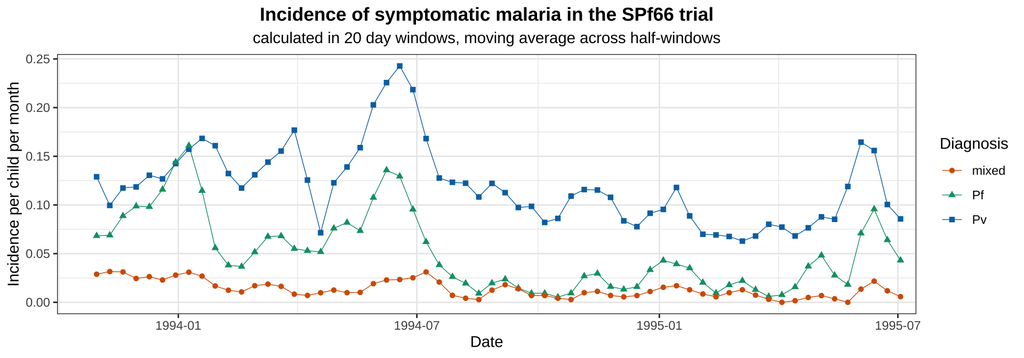

```r
MOVING_AV_TIME_STEP <- 2*TIME_STEP

patient_counts_with_masking <- lapply(masking_periods[c("Pv", "Pf", "mixed")], function(inf_type) {
  lapply(seq(1.5, STUDY_DURATION%/%MOVING_AV_TIME_STEP, 0.5), function(x) {
    masked_indiv <-
      inf_type %>% subset((START<=(x-1)*MOVING_AV_TIME_STEP & END>=(x-1)*MOVING_AV_TIME_STEP) |
                            (START<=x*MOVING_AV_TIME_STEP & END>=x*MOVING_AV_TIME_STEP)) %>%
      mutate(prop=(pmin(x*MOVING_AV_TIME_STEP, END)-pmax((x-1)*MOVING_AV_TIME_STEP,
                                                         START))/MOVING_AV_TIME_STEP) %>%
      dplyr::summarise(N_patients_masked=sum(prop)) %>%
      mutate(WINDOW=x)}) %>%
    bind_rows %>%
    merge(expand.grid(WINDOW=seq(1.5, STUDY_DURATION%/%MOVING_AV_TIME_STEP, 0.5))) %>%
    mutate(N_patients_masked=ifelse(is.na(N_patients_masked), 0, N_patients_masked),
           N_patients=N_COHORT-N_patients_masked,
           WINDOW_START=WINDOW-1)})


malaria_consultations_screened <- malaria_consultations_reconciled %>%
  dplyr::select(VIN, FALCIP, VIVAX, RelativeTime)

# clinical case counts -- moving average, half-windows
clinical_case_counts <-
  lapply(seq(1.5, STUDY_DURATION%/%MOVING_AV_TIME_STEP, 0.5), function(x) {
    malaria_consultations_screened %>%
      subset(RelativeTime>=(x-1)*MOVING_AV_TIME_STEP & RelativeTime<=x*MOVING_AV_TIME_STEP) %>%
      dplyr::summarise(N_Pf=sum(FALCIP),
                       N_Pv=sum(VIVAX),
                       N_mixed=sum(FALCIP*VIVAX)) %>%
      mutate(WINDOW=x)}) %>%
  bind_rows %>%
  merge(expand.grid(WINDOW=seq(1.5, STUDY_DURATION%/%MOVING_AV_TIME_STEP, 0.5))) %>%
  mutate(N_Pf=ifelse(is.na(N_Pf), 0, N_Pf),
         N_Pv=ifelse(is.na(N_Pv), 0, N_Pv),
         N_mixed=ifelse(is.na(N_mixed), 0, N_mixed),
         WINDOW_START=WINDOW-1)

incidence_by_window <-
  list(Pv=clinical_case_counts %>%
         transmute(WINDOW=WINDOW, WINDOW_START=WINDOW_START, N=N_Pv),
       Pf=clinical_case_counts %>%
         transmute(WINDOW=WINDOW, WINDOW_START=WINDOW_START, N=N_Pf),
       mixed=clinical_case_counts %>%
         transmute(WINDOW=WINDOW, WINDOW_START=WINDOW_START, N=N_mixed)) %>%
  purrr::map2(patient_counts_with_masking, function(n_cases, n_patients) {
    calc_incidence <- merge(n_cases, n_patients, all=TRUE) %>%
      mutate(WINDOW=as.numeric(WINDOW))
    calc_incidence[is.na(calc_incidence)] <- 0
    return(calc_incidence)}) %>%
  lapply(function(x) {
    x %>% mutate(incidence=N/N_patients*(365/MOVING_AV_TIME_STEP),
           Date=hours(WINDOW*MOVING_AV_TIME_STEP*24) + ymd(START_DATE))}) %>%
  bind_rows(.id="Diagnosis")

write_rds(incidence_by_window, "Spf66_data_processed/incidence_by_window.rds")
```

### Age structure in incidence

We calculate the incidence rate, stratified by age at enrolment, as the quotient of the total number of symptomatic malaria episodes recorded for an age group and the cumulative duration of clinical follow-up for the age group.

```r
age_counts <- patient_metadata %>% group_by(AGE) %>% summarise(count=n()) %>%
  mutate(count=factor(paste0(AGE, " years old\n(n=", count, ")"),
                      levels=paste0(2:15, " years old\n(n=", count, ")")))

N_BOOTSTRAP_REPLICATES <- 2000
incidence_bootstrap_resampling <- lapply(1:N_BOOTSTRAP_REPLICATES, function(i) {
  incidence_by_indiv[sample(1:N_COHORT, N_COHORT, replace=T),]})

incidence_by_indiv <- merge(incidence_by_indiv, age_counts)

incidence_rate <- list()

incidence_rate[["mixed"]] <- lapply(incidence_bootstrap_resampling, function(x) {
  x %>% group_by(AGE) %>% summarise(mean_incidence=sum(N_mixed)/sum(Followup_mixed))}) %>%
  bind_rows(.id="iter") %>%
  group_by(AGE) %>%
  summarise(`2.5%`=quantile(mean_incidence, 0.025),
            `50%`=quantile(mean_incidence, 0.5),
            `97.5%`=quantile(mean_incidence, 0.975))


incidence_rate[["Pf"]] <- lapply(incidence_bootstrap_resampling, function(x) {
  x %>% group_by(AGE) %>% summarise(mean_incidence=sum(N_Pf)/sum(Followup_Pf))}) %>%
  bind_rows(.id="iter") %>%
  group_by(AGE) %>%
  summarise(`2.5%`=quantile(mean_incidence, 0.025),
            `50%`=quantile(mean_incidence, 0.5),
            `97.5%`=quantile(mean_incidence, 0.975))

incidence_rate[["Pv"]] <- lapply(incidence_bootstrap_resampling, function(x) {
  x %>% group_by(AGE) %>% summarise(mean_incidence=sum(N_Pv)/sum(Followup_Pv))}) %>%
  bind_rows(.id="iter") %>%
  group_by(AGE) %>%
  summarise(`2.5%`=quantile(mean_incidence, 0.025),
            `50%`=quantile(mean_incidence, 0.5),
            `97.5%`=quantile(mean_incidence, 0.975))
```

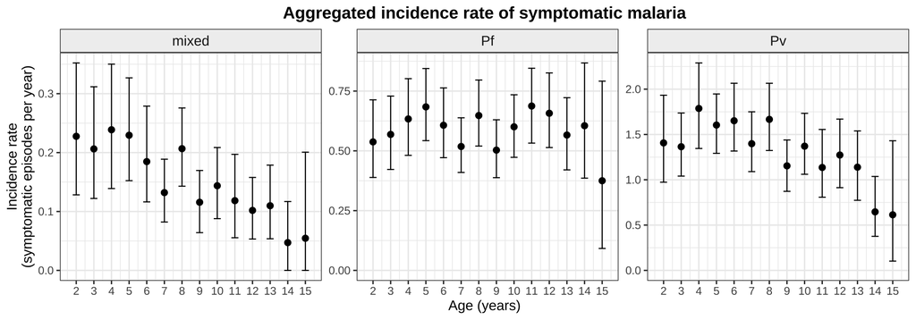

We additionally apply two non-parametric rank sum tests (namely, the Kruskall-Wallis test and the Mack-Wolfe test for umbrella alternatives with unknown peak) to the incidence per individual, stratified by age group.

```r
kruskall_wallis_pvals <-
  data.frame(variable=c("mixed", "Pf", "Pv"),
             pvalue=c(kruskal.test(Incidence_mixed ~ AGE, data = incidence_by_indiv)$p.value,
                      kruskal.test(Incidence_Pf ~ AGE, data = incidence_by_indiv)$p.value,
                      kruskal.test(Incidence_Pv ~ AGE, data = incidence_by_indiv)$p.value)) %>%
  mutate(pvalue=paste0("Kruskall-Wallis test: p-value ", round(pvalue, digits=5)))

mack_wolfe_Pv <- mackWolfeTest(Incidence_Pv ~ AGE, incidence_by_indiv, nperm=10000)
```

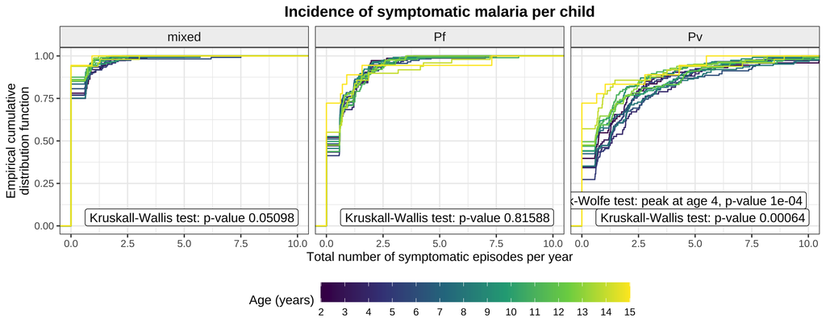

## Pre-processing for model calibration

### Longitudinal recurrence data

We seek to calibrate the within-host model to granular temporal recurrence data. Recorded clinical episodes for individuals aged 7 at enrolment are visualised below.

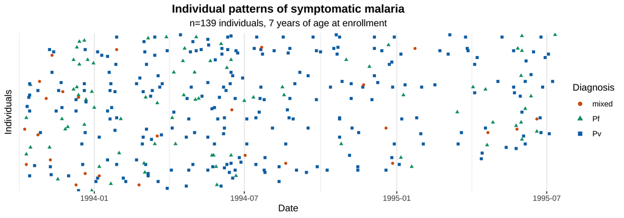

For simplicity, we discretise observations into 10 day windows. We assign a ternary infection state to each window: a contiguous string of Bs indicates a period of prophylactic bunching, culminating in a symptomatic episodes; C indicates a symptomatic episode within a window, with no prophylactic bunching; N indicates a window without a symptomatic episode, that does not fall into the prophylactic bunching period of a subsequent episode and for which clinical follow-up was performed for at least 5 days; while remaining windows with less than 5 days of clinical follow-up are masked as missing. Prior to adjusting for prophylaxis, we shift each clinical consultation to the midpoint of the relevant window.

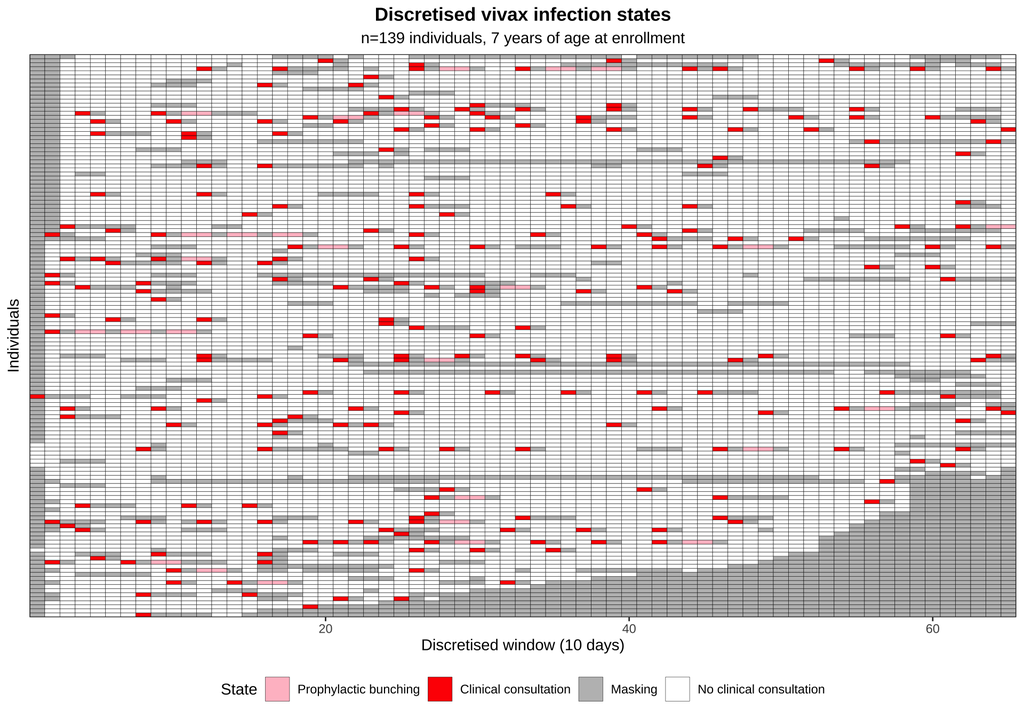

```r
keep_VIN <- as.character(patient_metadata$VIN)

malaria_consultations_reconciled <- malaria_consultations_reconciled %>%
  mutate(VIN=factor(VIN, levels=keep_VIN),
         RelativeTime=TIME_STEP*(RelativeTime%/%TIME_STEP)+TIME_STEP/2)

documented_absences <- masking_periods[["exc_prophylaxis"]] %>%
  mutate(VIN=factor(VIN, levels=keep_VIN))

# https://stackoverflow.com/questions/15235821/merge-overlapping-ranges-into-unique-groups-in-dataframe
# apply masking periods to shifted consultation times
masking_by_VIN <- malaria_consultations_reconciled %>%
  subset(VIVAX_MASKING>0) %>%
  transmute(VIN=VIN, START=RelativeTime, END=RelativeTime+VIVAX_MASKING) %>%
  bind_rows(documented_absences) %>%
  mutate(START=as.integer(START), END=as.integer(END)) %>%
  unique %>% split(f=.$VIN) %>% lapply(function(x) {
    x <- x %>% arrange(START)
    ir <- IRanges(x$START, x$END)
    x %>% mutate(my_group=subjectHits(findOverlaps(ir, reduce(ir)))) %>%
      group_by(my_group) %>%
      dplyr::summarise(START=min(START), END=max(END)) %>%
      dplyr::select(-my_group) %>% return})

bunching_by_VIN <- malaria_consultations_reconciled %>%
  subset(VIVAX_MASKING>0 & VIVAX_BUNCHING>0) %>% split(f=.$VIN) %>%
  lapply(function(x) {
    x %>% transmute(START=RelativeTime+VIVAX_MASKING,
              END=RelativeTime+VIVAX_MASKING+VIVAX_BUNCHING)})

consultation_times_by_VIN <- malaria_consultations_reconciled %>%
  subset(VIVAX==1) %>% split(f=.$VIN) %>% lapply(function(x) x$RelativeTime)


# PROP_MASKING: proportion of a window that must be spanned by
# prophylaxis or a documented camp absence to mandate masking

# string of Bs: prophylactic bunching, ending with detected clinical infection
# C: clinical infection within window, no bunching
# N: no clinical infection within window
# NA: masking (either due to prophylaxis or a documented absence from the camp)
discretised_inf_state <- function(consultation_times, masking, bunching,
                                  PROP_MASKED, PROP_BUNCHING=0.5) {
  inf_state <- rep("N", N_OBS)

  # calculate proportion of each window that is masked due to prophylaxis or absence
  proportion_masked <- rep(0, N_OBS)
  masking_windows <- masking %>%
    transmute(window_start=START%/%TIME_STEP+1, window_end=END%/%TIME_STEP+1,
              prop_window_start=1-(START%%TIME_STEP)/TIME_STEP,
              prop_window_end=(END%%TIME_STEP)/TIME_STEP)

  fully_masked <- masking_windows %>% subset(window_end-window_start>1) %>%
    apply(1, function(x) (x[1]+1):(x[2]-1))

  if (is.list(fully_masked)) fully_masked <- do.call(c, fully_masked)

  inf_state[fully_masked] <- "M"

  proportion_masked[masking_windows$window_start] <-
    proportion_masked[masking_windows$window_start] + masking_windows$prop_window_start

  proportion_masked[masking_windows$window_end] <-
    proportion_masked[masking_windows$window_end] + masking_windows$prop_window_end

  inf_state[which(proportion_masked>PROP_MASKED)] <- "M"

  # mark clinical consultation times
  clin_windows <- consultation_times%/%TIME_STEP+1
  inf_state[clin_windows] <- "C"

  # identify collisions between detected infections + propyhlactic bunching
  bunching_clin_collisions <-
    findOverlaps(IRanges(bunching$START, bunching$END),
                 IRanges(consultation_times)) %>% as.data.frame %>%
    transmute(START=bunching[queryHits, "START"],
              BUNCHING_START=ifelse(1-(START%%TIME_STEP)/TIME_STEP>PROP_BUNCHING,
                                    START%/%TIME_STEP+1, START%/%TIME_STEP+2),
              CLIN=consultation_times[subjectHits]%/%TIME_STEP+1) %>%
    subset(BUNCHING_START<CLIN) %>% select(-START) %>%
    apply(1, function(x) x[1]:x[2])

  if (is.list(bunching_clin_collisions)) bunching_clin_collisions <- do.call(c, bunching_clin_collisions)

  inf_state[bunching_clin_collisions] <- "B"
  return(inf_state[1:N_OBS])
}

inf_states_by_VIN <- lapply(keep_VIN, function(my_VIN) {
  discretised_inf_state(consultation_times_by_VIN[[my_VIN]],
                        masking_by_VIN[[my_VIN]],
                        bunching_by_VIN[[my_VIN]],
                        MAX_PROP_MASKED)})
names(inf_states_by_VIN) <- keep_VIN

write_rds(inf_states_by_VIN,
          "Spf66_data_processed/discretised_infection_matrix.rds")
```

### Seasonality

We infer seasonality in the force of inoculation for *P. vivax* from relative seasonal fluctuations in the incidence of falciparum malaria. Specifically, we fit a smoothing spline to the incidence of symptomatic falciparum (calculated in 20 day windows, with a moving average across half-windows) to obtain a discretised seasonality vector. To recover the force of inoculation for *P. vivax*, we apply a set of scaling factors to this seasonality vector (separate factors before and after window 20). We assume a constant force of inoculation prior to the study, equivalent to the mean force of inoculation in the first 20 windows of the study period.

```r
Pf_incidence <- incidence_by_window %>% subset(Diagnosis=="Pf") %>%
  transmute(WINDOW=2*TIME_STEP*(WINDOW_START+0.5), incidence=incidence)

seasonality_spline <- smooth.spline(Pf_incidence, df=24)

seasonality_pred <- predict(seasonality_spline, seq(1, N_OBS, 0.025)*TIME_STEP) %>% bind_rows

# normalise so average in first year is 1
# assume constant historical FORI, set to mean in first year
seasonality_vector <- predict(seasonality_spline, TIME_STEP*(1:N_OBS))$y
normalise_fact <- mean(seasonality_vector[1:SHIFT_WINDOW])
seasonality_vector <- seasonality_vector/normalise_fact
seasonality_vector <- c(rep(1, MAX_AGE), seasonality_vector)

write_rds(seasonality_vector, "Spf66_data_processed/seasonality_vector.rds")
```

The normalisation factor is 0.9408506 (relevant for calculating the ratio of the force of inoculation for vivax and falciparum respectively). After normalisation, the mean seasonality value after the shift window is 0.4780125.

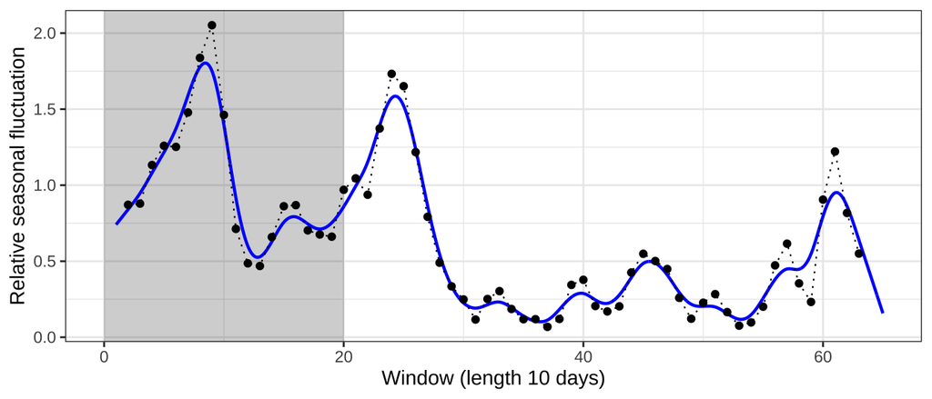